# Voxel level statistics for stained gray matter

W. Bauer

June 6, 2015

Earlier, probabilities of scattering, absorption, and encountering a boundary were estimated for voxels of the 11 BrainWeb tissue types. This note estimates corresponding statistics for stained gray matter using the same approach.

The absorption coefficient of stained gray matter will be the sum of $\mu_a \approx 0.0335\:mm^{-1},$ the absorption coefficient, $\mu_{a.dye},$ of the stain. The stain’s coefficient will depend on two things, its concentration and the local extent of depolarization. A 1 micromolar concentration of dye was estimated to have about the same absorption coefficient as gray matter itself. Depolarization might reduce that by as much as 30%.

Concentrations of 5 micromolars may not be unreasonable, so I’ll estimate statistics for 14 concentrations ranging from 2/3 to 5 micromolars by thirds. We’ve previously estimated a (full, not reduced) scattering coefficient of $\mu_s \approx 10\:mm^{-1}$ for gray matter. Staining should not affect it.

### Scattering probabilities

Following the procedure in Voxel Level Statistics,

```r
ranseed <- 1433640632 # system time when code was written
cnctr <- seq(2/3, 5, by=1/3) # concentrations
scatter <- data.frame(id=21:34,
                      tissue = paste(signif(cnctr,2), "umolar"),
                      mu_a = (1+cnctr)*0.0335,
                      mu_s = 10,
                      p_scatter=NA, std_err_scatter=NA)
for(i in 1:14){
  mua <- scatter[i, "mu_a"]
  mus <- scatter[i, "mu_s"]
  temp <- pscatter(mua,mus,1e+6,ranseed+i)
  scatter[i, "p_scatter"] <- temp$prscatt
  scatter[i, "std_err_scatter"] <- temp$se_scatt
}

scatter
```

```
##    id      tissue       mu_a mu_s p_scatter std_err_scatter
## 1  21 0.67 umolar 0.05583333   10  0.857812    0.0003492429
## 2  22    1 umolar 0.06700000   10  0.857146    0.0003499239
## 3  23  1.3 umolar 0.07816667   10  0.855843    0.0003512489
## 4  24  1.7 umolar 0.08933333   10  0.856045    0.0003510441
## 5  25    2 umolar 0.10050000   10  0.854901    0.0003522006
## 6  26  2.3 umolar 0.11166667   10  0.853806    0.0003533006
## 7  27  2.7 umolar 0.12283333   10  0.853592    0.0003535148
## 8  28    3 umolar 0.13400000   10  0.852111    0.0003549899
## 9  29  3.3 umolar 0.14516667   10  0.851481    0.0003556137
## 10 30  3.7 umolar 0.15633333   10  0.850976    0.0003561121
## 11 31    4 umolar 0.16750000   10  0.849793    0.0003572742
## 12 32  4.3 umolar 0.17866667   10  0.849474    0.0003575862
## 13 33  4.7 umolar 0.18983333   10  0.848115    0.0003589094
## 14 34    5 umolar 0.20100000   10  0.847251    0.0003597454
```

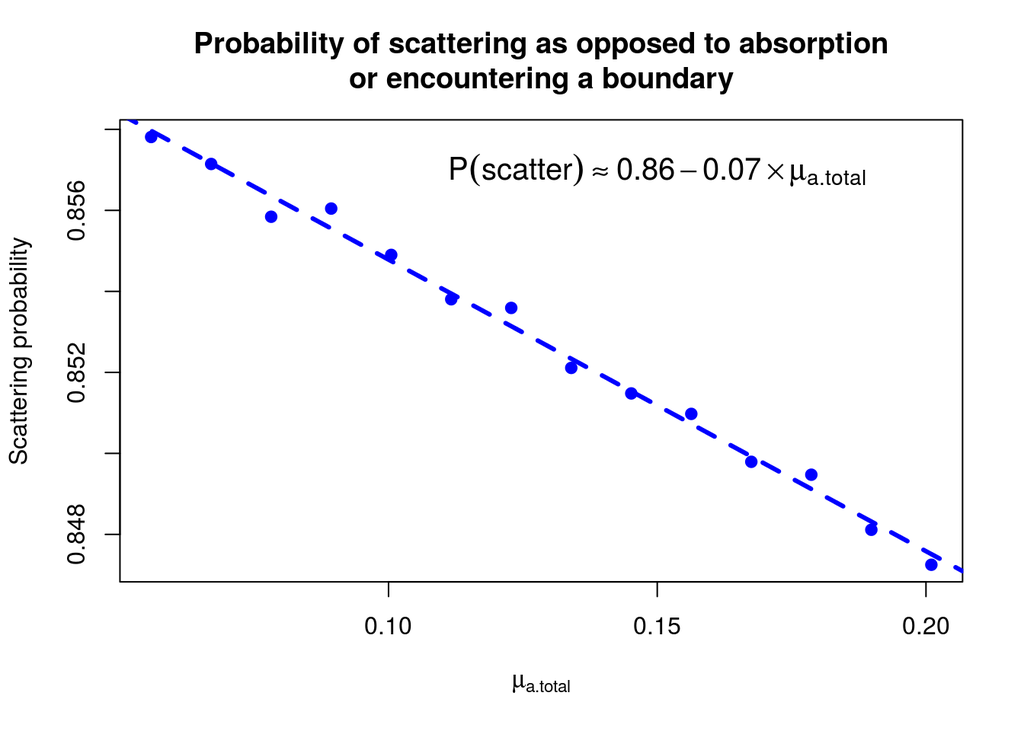

A photon’s probability of scattering, as opposed to being absorbed or encountering a voxel boundary, is linear in $\mu_a,$ at least over this range of $\mu_a$ values.